# team14-math

### Problem statement: The aim of this project is to predict a song popularity based on its lyrics. In simple terms, X would be songs lyrics, plain text written in English, and target label would be songs popularity. We've chosen the dataset from kaggle, https://www.kaggle.com/code/nuyangrai/spotify-songs-analysis. Firstly, we would try to explore data to gain insights. Secondly, we preprocess lyrics with the help of different NLP techniques. Thirdly, we create an embedding layer using glove 50d. Eventually, we build NN models with LSTM and Dense layers and try to play with different activation functions and hyper parameters to examine how the accuracy of the model, which is calculated by RMSE, would differentiate.

### Import libraries

```python
import numpy as np
import pandas as pd
import matplotlib.pyplot as plt
import seaborn as sns
import re

import nltk
from nltk.corpus import stopwords
from nltk.stem import WordNetLemmatizer

from sklearn.preprocessing import MinMaxScaler
from sklearn.model_selection import train_test_split

from keras.preprocessing.text import Tokenizer
from tensorflow.keras.preprocessing.sequence import pad_sequences

import tensorflow as tf
from keras.models import Sequential
from keras.layers import Dense
from keras.layers import LSTM
from tensorflow.keras.layers import Embedding, Dropout
from tensorflow.keras.optimizers import Adam, SGD, RMSprop

from keras.utils import plot_model

import warnings
warnings.filterwarnings("ignore")
```

### Import data set

```python
path_csv = r"Downloads/DL1/Ran's Project/spotify_songs.csv"
```

```python
songs = pd.read_csv(path_csv)
```

```python
songs.head()
```

|  | track_id | track_name | track_artist | lyrics | track_popularity | track_album_id | track_album_name | track_album_release_date | playlist_name | playlist_id | ... | loudness | mode | speechiness | acousticness | instrumentalness | liveness | valence | tempo | duration_ms | language |
| --- | --- | --- | --- | --- | --- | --- | --- | --- | --- | --- | --- | --- | --- | --- | --- | --- | --- | --- | --- | --- | --- |
| 0 | 0017A6SJgTbfQVU2EtsPNo | Pangarap | Barbie's Cradle | Minsan pa Nang ako'y napalingon Hindi ko alam ... | 41 | 1srJQ0njEQgd8w4XSqI4JQ | Trip | 2001-01-01 | Pinoy Classic Rock | 37i9dQZF1DWYDQ8wBxd7xt | ... | -10.068 | 1 | 0.0236 | 0.27900 | 0.01170 | 0.0887 | 0.566 | 97.091 | 235440 | tl |
| 1 | 004s3t0ONYlzxII9PLgU6z | I Feel Alive | Steady Rollin | The trees, are singing in the wind The sky blu... | 28 | 3z04Lb9Dsilqw68SHt6jLB | Love & Loss | 2017-11-21 | Hard Rock Workout | 3YouF0u7waJnolytf9JCXf | ... | -4.739 | 1 | 0.0442 | 0.01170 | 0.00994 | 0.3470 | 0.404 | 135.225 | 373512 | en |
| 2 | 00chLpzhgVjxs1zKC9UScL | Poison | Bell Biv DeVoe | NA Yeah, Spyderman and Freeze in full effect U... | 0 | 6oZ6brjB8x3GoeSYdwJdPc | Gold | 2005-01-01 | Back in the day - R&B, New Jack Swing, Swingbe... | 3a9y4eeCJRmG9p4YKfqYIx | ... | -7.504 | 0 | 0.2160 | 0.00432 | 0.00723 | 0.4890 | 0.650 | 111.904 | 262467 | en |
| 3 | 00cqd6ZsSkLZqGMlQCR0Zo | Baby It's Cold Outside (feat. Christina Aguilera) | CeeLo Green | I really can't stay Baby it's cold outside I'v... | 41 | 3ssspRe42CXkhPxdc12xcp | CeeLo's Magic Moment | 2012-10-29 | Christmas Soul | 6FZYc2BvF7tColxO8PBShV | ... | -5.819 | 0 | 0.0341 | 0.68900 | 0.00000 | 0.0664 | 0.405 | 118.593 | 243067 | en |
| 4 | 00emjlCv9azBN0fzuuyLqy | Dumb Litty | KARD | Get up out of my business You don't keep me fr... | 65 | 7h5X3xhh3peIK9Y0qI5hbK | KARD 2nd Digital Single ‘Dumb Litty’ | 2019-09-22 | K-Party Dance Mix | 37i9dQZF1DX4RDXswvP6Mj | ... | -1.993 | 1 | 0.0409 | 0.03700 | 0.00000 | 0.1380 | 0.240 | 130.018 | 193160 | en |

5 rows × 25 columns

```python
# for further visualizations
duration_min = songs['duration_ms'].apply(lambda duration: (duration/1000)//60)
songs['duration_min'] = duration_min

loudness = songs['loudness']
valence = songs['valence']
tempo = songs['tempo']
```

### Preprocessing

```python
songs.columns
```

```
Index(['track_id', 'track_name', 'track_artist', 'lyrics', 'track_popularity',
       'track_album_id', 'track_album_name', 'track_album_release_date',
       'playlist_name', 'playlist_id', 'playlist_genre', 'playlist_subgenre',
       'danceability', 'energy', 'key', 'loudness', 'mode', 'speechiness',
       'acousticness', 'instrumentalness', 'liveness', 'valence', 'tempo',
       'duration_ms', 'language', 'duration_min'],
      dtype='object')
```

```python
# we don't need these features
songs = songs.drop(columns=['track_id', 'track_name', 'track_album_id', 'track_album_name', 'playlist_name', 'playlist_id', 'key', 'loudness', 'mode', 'speechiness', 'acousticness', 'liveness', 'valence', 'tempo', 'duration_ms'])
```

```python
songs.info()
```

```
<class 'pandas.core.frame.DataFrame'>
RangeIndex: 18454 entries, 0 to 18453
Data columns (total 11 columns):
 #   Column                    Non-Null Count  Dtype
---  ------                    --------------  -----
 0   track_artist              18454 non-null  object
 1   lyrics                    18194 non-null  object
 2   track_popularity          18454 non-null  int64
 3   track_album_release_date  18454 non-null  object
 4   playlist_genre            18454 non-null  object
 5   playlist_subgenre         18454 non-null  object
 6   danceability              18454 non-null  float64
 7   energy                    18454 non-null  float64
 8   instrumentalness          18454 non-null  float64
 9   language                  18194 non-null  object
 10  duration_min              18454 non-null  float64
dtypes: float64(4), int64(1), object(6)
memory usage: 1.5+ MB
```

```python
# remove all rows which contain null value
null_rows = songs[songs['lyrics'].isnull()].index
```

```python
songs = songs.drop(index = null_rows)
```

```python
songs.info()
```

```
<class 'pandas.core.frame.DataFrame'>
Int64Index: 18194 entries, 0 to 18453
Data columns (total 11 columns):
 #   Column                    Non-Null Count  Dtype
---  ------                    --------------  -----
 0   track_artist              18194 non-null  object
 1   lyrics                    18194 non-null  object
 2   track_popularity          18194 non-null  int64
 3   track_album_release_date  18194 non-null  object
 4   playlist_genre            18194 non-null  object
 5   playlist_subgenre         18194 non-null  object
 6   danceability              18194 non-null  float64
 7   energy                    18194 non-null  float64
 8   instrumentalness          18194 non-null  float64
 9   language                  18194 non-null  object
 10  duration_min              18194 non-null  float64
dtypes: float64(4), int64(1), object(6)
memory usage: 1.7+ MB
```

```python
songs = songs.reset_index().drop(columns = 'index')
```

```python
songs.head()
```

|  | track_artist | lyrics | track_popularity | track_album_release_date | playlist_genre | playlist_subgenre | danceability | energy | instrumentalness | language | duration_min |
| --- | --- | --- | --- | --- | --- | --- | --- | --- | --- | --- | --- |
| 0 | Barbie's Cradle | Minsan pa Nang ako'y napalingon Hindi ko alam ... | 41 | 2001-01-01 | rock | classic rock | 0.682 | 0.401 | 0.01170 | tl | 3.0 |
| 1 | Steady Rollin | The trees, are singing in the wind The sky blu... | 28 | 2017-11-21 | rock | hard rock | 0.303 | 0.880 | 0.00994 | en | 6.0 |
| 2 | Bell Biv DeVoe | NA Yeah, Spyderman and Freeze in full effect U... | 0 | 2005-01-01 | r&b | new jack swing | 0.845 | 0.652 | 0.00723 | en | 4.0 |
| 3 | CeeLo Green | I really can't stay Baby it's cold outside I'v... | 41 | 2012-10-29 | r&b | neo soul | 0.425 | 0.378 | 0.00000 | en | 4.0 |
| 4 | KARD | Get up out of my business You don't keep me fr... | 65 | 2019-09-22 | pop | dance pop | 0.760 | 0.887 | 0.00000 | en | 3.0 |

### Data exploration

```python
# we can only perfom NLP tasks on english lyrics
en_songs = songs[songs['language'] == 'en'].reset_index(drop = True)
```

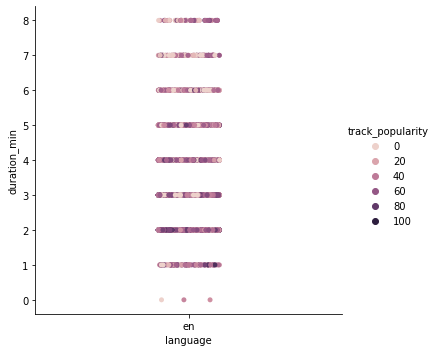

```python
# popularity based on the song duration
sns.catplot(x = 'language', y = 'duration_min', hue = 'track_popularity', data = en_songs)
plt.show()
```

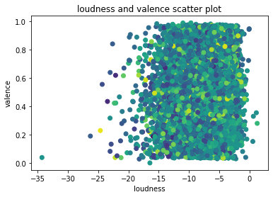

```python
plt.scatter(loudness, valence, c=tempo, cmap='viridis')
plt.xlabel('loudness')
plt.ylabel('valence')
plt.title('loudness and valence scatter plot');
```

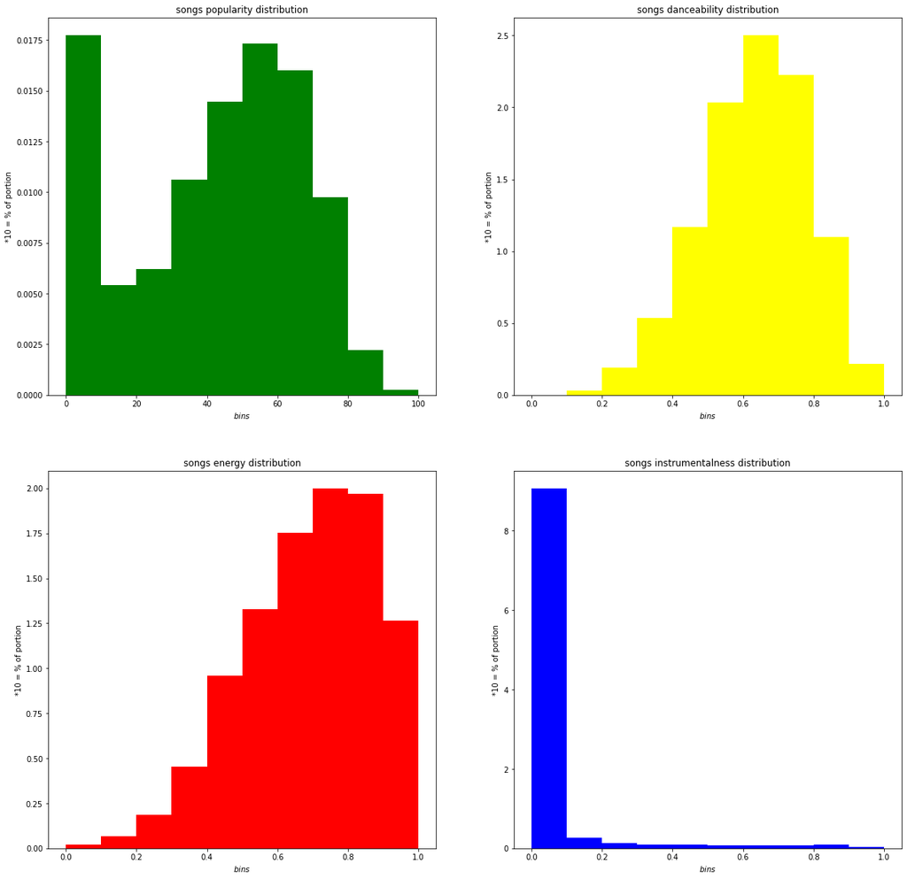

```python
plt.figure(figsize=(20,20))
plt.subplot(2,2,1)
plt.hist(en_songs['track_popularity'], bins = np.linspace(0,100,11), density = True, color = 'green')
plt.title('songs popularity distribution')
plt.xlabel('$bins$')
plt.ylabel('*10 = % of portion');
plt.subplot(2,2,2)
plt.hist(en_songs['danceability'], bins = np.linspace(0,1,11), density = True, color = 'yellow')
plt.title('songs danceability distribution')
plt.xlabel('$bins$')
plt.ylabel('*10 = % of portion');
plt.subplot(2,2,3)
plt.hist(en_songs['energy'], bins = np.linspace(0,1,11), density = True, color = 'red')
plt.title('songs energy distribution')
plt.xlabel('$bins$')
plt.ylabel('*10 = % of portion');
plt.subplot(2,2,4)
plt.hist(en_songs['instrumentalness'], bins = np.linspace(0,1,11), density = True, color = 'blue')
plt.title('songs instrumentalness distribution')
plt.xlabel('$bins$')
plt.ylabel('*10 = % of portion');
```

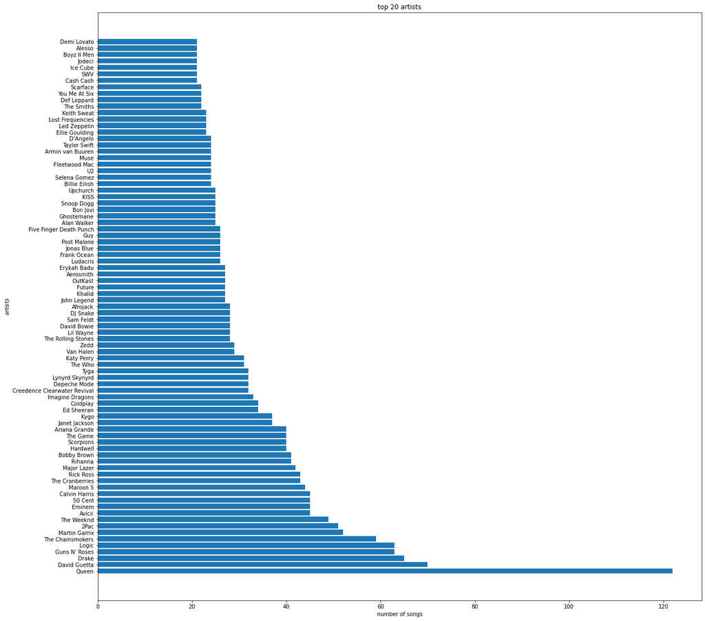

```python
plt.figure(figsize=(20,20))
artists = en_songs['track_artist'].apply(lambda track_artist: re.sub('\$', 's', track_artist))
top_artists = artists.value_counts()[artists.value_counts().values > 20]
plt.barh(top_artists.index, top_artists.values)
plt.title('top 20 artists')
plt.xlabel('number of songs')
plt.ylabel('$artists$');
```

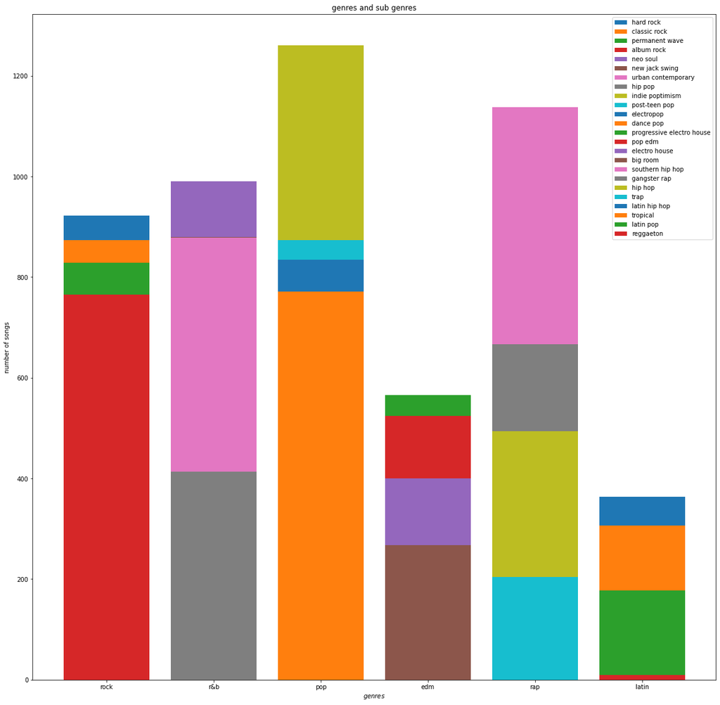

```python
plt.figure(figsize = (20,20))
plt.title('genres and sub genres')
plt.xlabel('$genres$')
plt.ylabel('number of songs')
for genre in en_songs['playlist_genre'].unique():
    sub_genres = en_songs[en_songs['playlist_genre'] == genre]['playlist_subgenre'].value_counts()
    for sub_genre in sub_genres.index:
        plt.bar(genre, int(sub_genres[sub_genres.index == sub_genre].values), label = sub_genre)
        plt.legend(loc = 'best')
```

### Data preprocessing

```python
en_songs.info()
```

```
<class 'pandas.core.frame.DataFrame'>
RangeIndex: 15405 entries, 0 to 15404
Data columns (total 11 columns):
 #   Column                    Non-Null Count  Dtype
---  ------                    --------------  -----
 0   track_artist              15405 non-null  object
 1   lyrics                    15405 non-null  object
 2   track_popularity          15405 non-null  int64
 3   track_album_release_date  15405 non-null  object
 4   playlist_genre            15405 non-null  object
 5   playlist_subgenre         15405 non-null  object
 6   danceability              15405 non-null  float64
 7   energy                    15405 non-null  float64
 8   instrumentalness          15405 non-null  float64
 9   language                  15405 non-null  object
 10  duration_min              15405 non-null  float64
dtypes: float64(4), int64(1), object(6)
memory usage: 1.3+ MB
```

```python
stop_words = set(stopwords.words('english'))
lemmatizer = WordNetLemmatizer()

def preprocess_lyrics(lyrics):
    '''remove stop words and all extra characters from lyrics'''
    lyrics = lyrics.lower()
    lyrics = re.sub('n\'t', ' not', lyrics)
    lyrics = re.sub('\'s', ' is', lyrics)
    lyrics = re.sub('\'m', ' am', lyrics)
    lyrics = re.sub('\'ll', ' will', lyrics)
    lyrics = re.sub('\'re', ' are', lyrics)
    lyrics = re.sub('\'d', ' would', lyrics)
    lyrics = re.sub('\'', '', lyrics)
    lyrics = re.sub('[^a-z\s]',' ', lyrics) #removes any character rather than a-z and white space from text
    lyrics = re.sub('\s+', ' ', lyrics) #converts any more than one space to one space
    lyrics = [lemmatizer.lemmatize(word) for word in lyrics.split() if word not in stop_words]
    lyrics = ' '.join(lyrics)
    return lyrics
```

```python
# preprocess all the lyrics using preprocess_lyrics function
processed_lyrics = en_songs['lyrics'].apply(preprocess_lyrics)
```

```python
# eventually, here is the dataset which we are going to build and train the models with
lyrics_popularity = pd.DataFrame(columns = ['lyrics', 'popularity'])
lyrics_popularity['lyrics'] = processed_lyrics
lyrics_popularity['popularity'] = en_songs['track_popularity']
lyrics_popularity.head()
```

|  | lyrics | popularity |
| --- | --- | --- |
| 0 | tree singing wind sky blue angel smiled saw lo... | 28 |
| 1 | na yeah spyderman freeze full effect uh huh re... | 0 |
| 2 | really ca stay baby cold outside ive got go aw... | 41 |
| 3 | get business keep turning witness criminal fee... | 65 |
| 4 | hold breath look keep trying darling okay scar... | 70 |

```python
X = lyrics_popularity['lyrics']
y = lyrics_popularity['popularity']
```

### Normalization

```python
# normalizing target value, songs popularity
scaler = MinMaxScaler()
y_norm = scaler.fit_transform(np.array(y).reshape(-1, 1))
```

### Split data into train and test

```python
X_train, X_test, y_train, y_test = train_test_split(X, y_norm, test_size = 0.33, random_state = 42)
```

### Tokenization

```python
# tokenize words, assign an unique number to each word in the lyrics
num_words_ = 5000
oov_tok = "<OOV>"

tokenizer = Tokenizer(num_words = num_words_, oov_token = oov_tok)
tokenizer.fit_on_texts(X_train)

X_train = tokenizer.texts_to_sequences(X_train)
X_test = tokenizer.texts_to_sequences(X_test)
```

### Pad Sequencing

```python
# using pad sequencing to make the length of the inputs equal, necessary for training models
vocab_size = len(tokenizer.word_index) + 1

maxlen = 300
trunc_type='post'
padding_type='post'

X_train = pad_sequences(X_train, padding = padding_type, maxlen = maxlen, truncating = trunc_type)
X_test = pad_sequences(X_test, padding = padding_type, maxlen = maxlen, truncating = trunc_type)
```

### Embedding dictionary using 50 dimensional glove

```python
# creating embedding layer using glove 50 dimensional dictionary
embeddings_dictionary = dict()
glove_file = open(r'Downloads/DL1/Moe DL1/Project/glove.6B.50d.txt', encoding="utf8")

for line in glove_file:
    records = line.split()
    word = records[0]
    vector_dimensions = np.asarray(records[1:], dtype = 'float32')
    embeddings_dictionary[word] = vector_dimensions

glove_file.close()
```

```python
embedding_matrix = np.zeros((vocab_size, 50))
for word, index in tokenizer.word_index.items():
    embedding_vector = embeddings_dictionary.get(word)
    if embedding_vector is not None:
        embedding_matrix[index] = embedding_vector
```

### Building Models

```python
# first model
# 4 hidden layers
# output layer has only 1 node which is going to calculate the song popularity

model1 = Sequential()
embedding_layer = Embedding(vocab_size, 50, weights=[embedding_matrix], input_length=maxlen , trainable=False)

model1.add(embedding_layer)   #hidden1, the Embedding layer, takes the input data and converts it into dense vectors of fixed size
model1.add(LSTM(32, activation='relu', kernel_regularizer = tf.keras.regularizers.L1(0.01), return_sequences=True)) #hidden2: LSTM, 32 nodes and relu as activation function. adding L1 regularization
model1.add(LSTM(32, activation='relu'))                                                                             #hidden3: LSTM, 32 nodes and relu as activation function
model1.add(Dense(16, activation='relu'))                                                                            #hidden4: Dense, 16 nodes and relu as activation function
model1.add(Dense(1, activation= 'relu' ))                                                                           #output: Dense, 1 nodes and relu as activation function

model1.compile(optimizer = 'adam', loss = 'mean_squared_error', metrics = [tf.keras.metrics.RootMeanSquaredError()])#adam as the optimizer and mse to calculate loss function
```

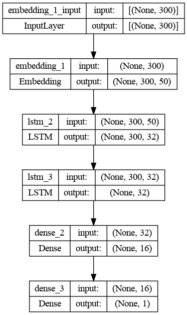

```python
# plot model1 architecture
plot_model(model1, to_file="Downloads/DL1/Ran's Project/model1.png", show_shapes=True, show_layer_names=True)
```

```python
performance1 = model1.fit(X_train, y_train, validation_split=0.2, batch_size = 64, epochs = 20)
```

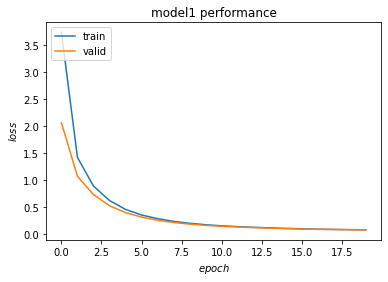

```python
plt.plot(performance1.history['loss'])
plt.plot(performance1.history['val_loss'])
plt.title('model1 performance')
plt.ylabel('$loss$')
plt.xlabel('$epoch$')
plt.legend(['train','valid'], loc='upper left')
plt.show()
```

### model1 is doing good at predicting target values, the minimum amount of loss function is 0.08. we can see that after 15 epochs the loss function is slowly getting close to 0

```python
# second model
# 4 hidden layers
# output layer has only 1 node which is going to calculate the song popularity

model2 = Sequential()
embedding_layer = Embedding(vocab_size, 50, weights=[embedding_matrix], input_length=maxlen , trainable=False)

model2.add(embedding_layer)                                    #hidden1, the Embedding layer, takes the input data and converts it into dense vectors of fixed size
model2.add(LSTM(16, activation='tanh', return_sequences=True)) #hidden2: LSTM, 16 nodes and tanh as activation function
model2.add(LSTM(16, activation='tanh'))                        #hidden3: LSTM, 16 nodes and tanh as activation function
model2.add(Dense(8, activation='tanh'))                        #hidden4: Dense, 8 nodes and tanh as activation function
model2.add(Dense(1, activation= 'relu' ))                      #output: Dense, 1 nodes and relu as activation function

model2.compile(optimizer = 'adam', loss = 'mean_squared_error', metrics = [tf.keras.metrics.RootMeanSquaredError()]) #adam as the optimizer and mse to calculate loss function
```

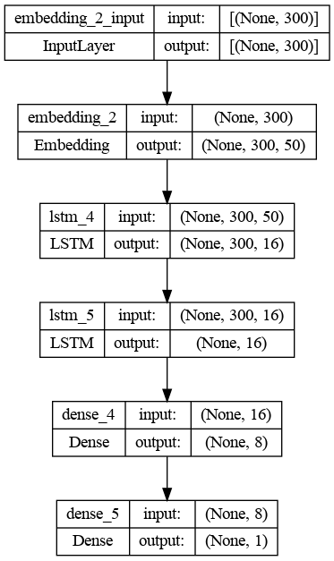

```python
# plot model2 architecture
plot_model(model2, to_file="Downloads/DL1/Ran's Project/model2.png", show_shapes=True, show_layer_names=True)
```

```python
performance2 = model2.fit(X_train, y_train, validation_split=0.2, batch_size = 64, epochs = 20)
```

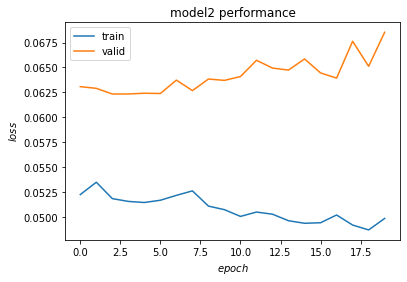

```python
plt.plot(performance2.history['loss'])
plt.plot(performance2.history['val_loss'])
plt.title('model2 performance')
plt.ylabel('$loss$')
plt.xlabel('$epoch$')
plt.legend(['train','valid'], loc='upper left')
plt.show()
```

```python
# model2 with drop out which is a regularization technique to prevent overfitting
# drop out forces the model to learn multiple independent representations of the input data by randomly sets a portion of the activations, here 70%, from the previous layer to zero
# 4 hidden layers
# output layer has only 1 node which is going to calculate the song popularity

model2_do = Sequential()
embedding_layer = Embedding(vocab_size, 50, weights=[embedding_matrix], input_length=maxlen , trainable=False)

model2_do.add(embedding_layer)                                    #hidden1, the Embedding layer, takes the input data and converts it into dense vectors of fixed size
model2_do.add(LSTM(16, activation='tanh', return_sequences=True)) #hidden2: LSTM, 16 nodes and tanh as activation function
model2_do.add(Dropout(0.7))
model2_do.add(LSTM(16, activation='tanh'))                        #hidden3: LSTM, 16 nodes and tanh as activation function
model2_do.add(Dropout(0.7))
model2_do.add(Dense(8, activation='tanh'))                        #hidden4: Dense, 8 nodes and tanh as activation function
model2_do.add(Dropout(0.6))
model2_do.add(Dense(1, activation= 'relu' ))                      #output: Dense, 1 nodes and relu as activation function

model2_do.compile(optimizer = 'adam', loss = 'mean_squared_error', metrics = [tf.keras.metrics.RootMeanSquaredError()]) #adam as the optimizer and mse to calculate loss function
```

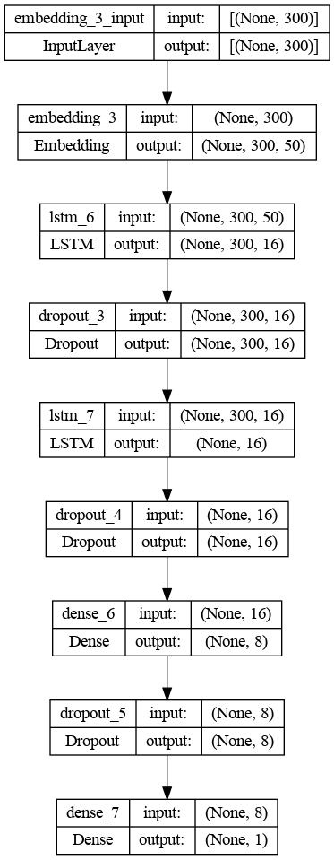

```python
# plot model2 with drop out architecture
plot_model(model2_do, to_file="Downloads/DL1/Ran's Project/model2_do.png", show_shapes=True, show_layer_names=True)
```

```python
performance2_do = model2_do.fit(X_train, y_train, validation_split=0.2, batch_size = 64, epochs = 20)
```

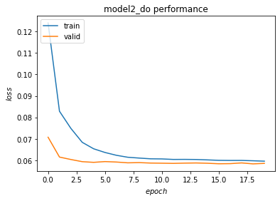

```python
plt.plot(performance2_do.history['loss'])
plt.plot(performance2_do.history['val_loss'])
plt.title('model2_do performance')
plt.ylabel('$loss$')
plt.xlabel('$epoch$')
plt.legend(['train','valid'], loc='upper left')
plt.show()
```